# BGC X GenAI Task 1

```python
import pandas as pd
import matplotlib.pyplot as plt
```

## Data collection and loading

- Data collected under several assumptions:
  - For `Tesla`, "Net cash provided by operating activities" under "Cash Flow from Operating Activities" = "Cash Flow from Operating Activities"
  - For `Apple`, "Total net sales" = "Total Revenue".
- Encoding done to deal with leading whitespaces.
- `pct_change()` uses the current and prior data to obtain the result, so `Year` was set in ascending order.

```python
df = pd.read_csv('BGC_X_GenAI_Task_1.csv', encoding='utf-8-sig', sep='\s*,\s*', engine='python')
df = df[df['Company'].notna()] # https://stackoverflow.com/questions/13413590/how-to-drop-rows-of-pandas-dataframe-whose-value-in-a-certain-column-is-nan
display(df)
```

|  | Company | Year | Total Revenue | Net Income | Total Assets | Total Liabilities | Cash Flow from Operating Activities |
| --- | --- | --- | --- | --- | --- | --- | --- |
| 0 | Microsoft | 2021.0 | 168088.0 | 61271.0 | 333779.0 | 191791.0 | 76740.0 |
| 1 | Microsoft | 2022.0 | 198270.0 | 72738.0 | 364840.0 | 198298.0 | 89035.0 |
| 2 | Microsoft | 2023.0 | 211915.0 | 72361.0 | 411976.0 | 205753.0 | 87582.0 |
| 3 | Tesla | 2021.0 | 53823.0 | 5644.0 | 62131.0 | 30548.0 | 5644.0 |
| 4 | Tesla | 2022.0 | 81462.0 | 12587.0 | 82338.0 | 36440.0 | 12587.0 |
| 5 | Tesla | 2023.0 | 96773.0 | 14974.0 | 106618.0 | 43009.0 | 14974.0 |
| 6 | Apple | 2021.0 | 365817.0 | 94680.0 | 351002.0 | 287912.0 | 104038.0 |
| 7 | Apple | 2022.0 | 394328.0 | 99803.0 | 352755.0 | 302083.0 | 122151.0 |
| 8 | Apple | 2023.0 | 383285.0 | 96995.0 | 352583.0 | 290437.0 | 110543.0 |

## Feature engineering

- Growth columns created to analyse year-over-year changes in financial metrics.
- Profit margin as measure of profitability of business.
  - Profit margin = $\frac{\text{Net Income}}{\text{Total Revenue}}$
- Return on assets as measure of business asset utilisation.
  - Return on assets = $\frac{\text{Net Income}}{\text{Total Assets}}$
- Operating cash flow ratio as measure of operational efficiency.
  - Operating cash flow ratio = $\frac{\text{Operating Cash Flow}}{\text{Total Revenue}}$

```python
df['Revenue Growth (%)'] = df.groupby(['Company'])['Total Revenue'].pct_change() * 100
df['Net Income Growth (%)'] = df.groupby(['Company'])['Net Income'].pct_change() * 100
df['Asset Growth (%)'] = df.groupby(['Company'])['Total Assets'].pct_change() * 100
df['Liability Growth (%)'] = df.groupby(['Company'])['Total Liabilities'].pct_change() * 100
df['Cash Flow Growth (%)'] = df.groupby(['Company'])['Cash Flow from Operating Activities'].pct_change() * 100

df['Profit Margin'] = df['Net Income'] / df['Total Revenue']
df['Return On Assets'] = df['Net Income'] / df['Total Assets']
df['Operating Cash Flow Ratio'] = df['Cash Flow from Operating Activities'] / df['Total Revenue']
display(df)
```

|  | Company | Year | Total Revenue | Net Income | Total Assets | Total Liabilities | Cash Flow from Operating Activities | Revenue Growth (%) | Net Income Growth (%) | Asset Growth (%) | Liability Growth (%) | Cash Flow Growth (%) | Profit Margin | Return On Assets | Operating Cash Flow Ratio |
| --- | --- | --- | --- | --- | --- | --- | --- | --- | --- | --- | --- | --- | --- | --- | --- |
| 0 | Microsoft | 2021.0 | 168088.0 | 61271.0 | 333779.0 | 191791.0 | 76740.0 | NaN | NaN | NaN | NaN | NaN | 0.364517 | 0.183568 | 0.456547 |
| 1 | Microsoft | 2022.0 | 198270.0 | 72738.0 | 364840.0 | 198298.0 | 89035.0 | 17.956071 | 18.715216 | 9.305858 | 3.392756 | 16.021631 | 0.366863 | 0.199370 | 0.449059 |
| 2 | Microsoft | 2023.0 | 211915.0 | 72361.0 | 411976.0 | 205753.0 | 87582.0 | 6.882030 | -0.518299 | 12.919636 | 3.759493 | -1.631942 | 0.341462 | 0.175644 | 0.413288 |
| 3 | Tesla | 2021.0 | 53823.0 | 5644.0 | 62131.0 | 30548.0 | 5644.0 | NaN | NaN | NaN | NaN | NaN | 0.104862 | 0.090840 | 0.104862 |
| 4 | Tesla | 2022.0 | 81462.0 | 12587.0 | 82338.0 | 36440.0 | 12587.0 | 51.351653 | 123.015592 | 32.523217 | 19.287678 | 123.015592 | 0.154514 | 0.152870 | 0.154514 |
| 5 | Tesla | 2023.0 | 96773.0 | 14974.0 | 106618.0 | 43009.0 | 14974.0 | 18.795267 | 18.964010 | 29.488207 | 18.026894 | 18.964010 | 0.154733 | 0.140445 | 0.154733 |
| 6 | Apple | 2021.0 | 365817.0 | 94680.0 | 351002.0 | 287912.0 | 104038.0 | NaN | NaN | NaN | NaN | NaN | 0.258818 | 0.269742 | 0.284399 |
| 7 | Apple | 2022.0 | 394328.0 | 99803.0 | 352755.0 | 302083.0 | 122151.0 | 7.793788 | 5.410858 | 0.499427 | 4.921990 | 17.409985 | 0.253096 | 0.282924 | 0.309770 |
| 8 | Apple | 2023.0 | 383285.0 | 96995.0 | 352583.0 | 290437.0 | 110543.0 | -2.800461 | -2.813543 | -0.048759 | -3.855232 | -9.502992 | 0.253062 | 0.275098 | 0.288409 |

## `df.info()`

- All variables except for `Company` and `Year` are numeric.
- `Company` and `Year` are meant to be categorical.

```python
display(df.info())
```

```
<class 'pandas.core.frame.DataFrame'>
Index: 9 entries, 0 to 8
Data columns (total 15 columns):
 #   Column                               Non-Null Count  Dtype
---  ------                               --------------  -----
 0   Company                              9 non-null      object
 1   Year                                 9 non-null      float64
 2   Total Revenue                        9 non-null      float64
 3   Net Income                           9 non-null      float64
 4   Total Assets                         9 non-null      float64
 5   Total Liabilities                    9 non-null      float64
 6   Cash Flow from Operating Activities  9 non-null      float64
 7   Revenue Growth (%)                   6 non-null      float64
 8   Net Income Growth (%)                6 non-null      float64
 9   Asset Growth (%)                     6 non-null      float64
 10  Liability Growth (%)                 6 non-null      float64
 11  Cash Flow Growth (%)                 6 non-null      float64
 12  Profit Margin                        9 non-null      float64
 13  Return On Assets                     9 non-null      float64
 14  Operating Cash Flow Ratio            9 non-null      float64
dtypes: float64(14), object(1)
memory usage: 1.1+ KB
```

```
None
```

```python
# display(df.describe())
```

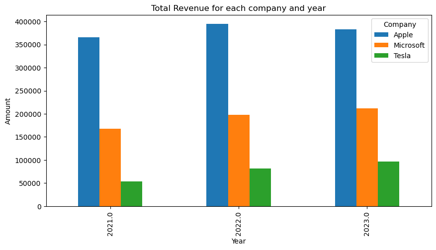

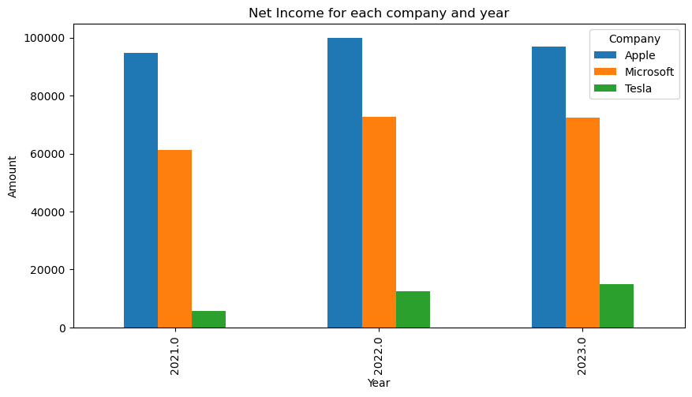

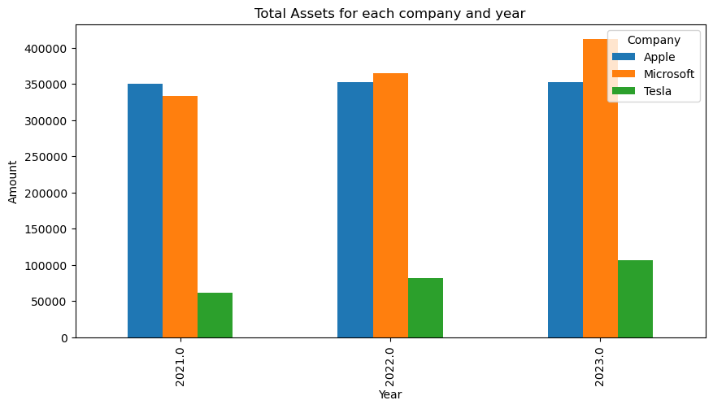

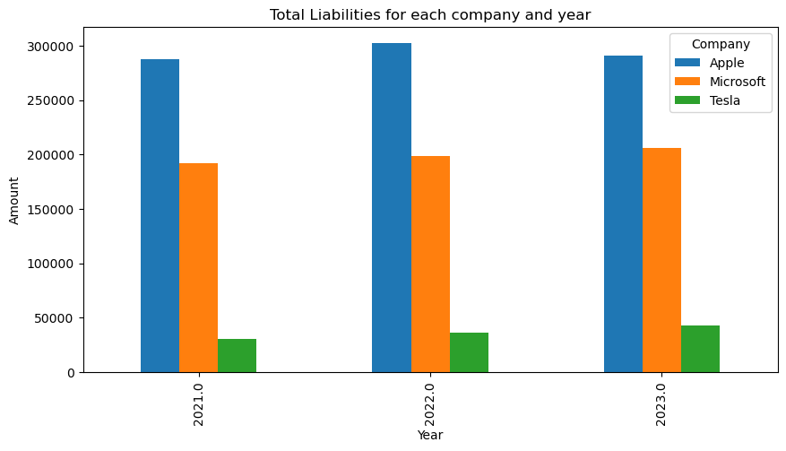

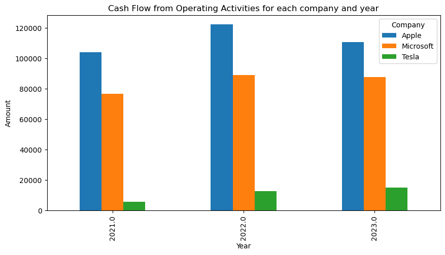

```python
numericcats = ["Total Revenue", "Net Income", "Total Assets", "Total Liabilities", "Cash Flow from Operating Activities"]
for n in numericcats:
    df.groupby(['Year', 'Company'])[n].sum().unstack().plot(kind='bar', figsize=(10, 5))
    plt.title(str(n) + " for each company and year")
    plt.xlabel("Year")
    plt.ylabel('Amount')
    plt.show()
```

- Growth is relative to 1 year prior to the given year.
- `dropna()` is applied since there is no growth from 2020 to 2021 provided in the data.
- Tesla has significantly higher growth for each metric compared to Apple and Microsoft, but the metric growths from 2022 to 2023 are lower than the metric growths from 2021 to 2022.
- Apple's metric growths are all positive from 2021 to 2022, and negative or 0% from 2022 to 2023.
- Microsoft's growths for revenue, net income, and cash flow decrease over time, while their growth in assets and liabilities are slightly increased over time.

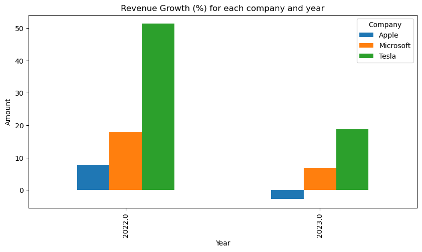

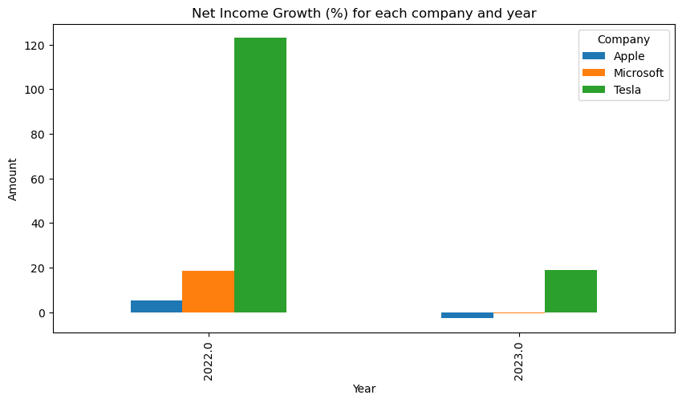

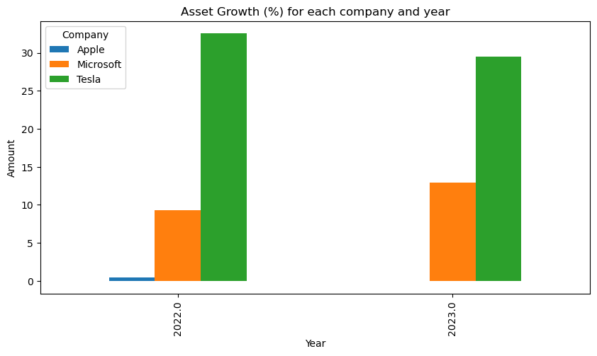

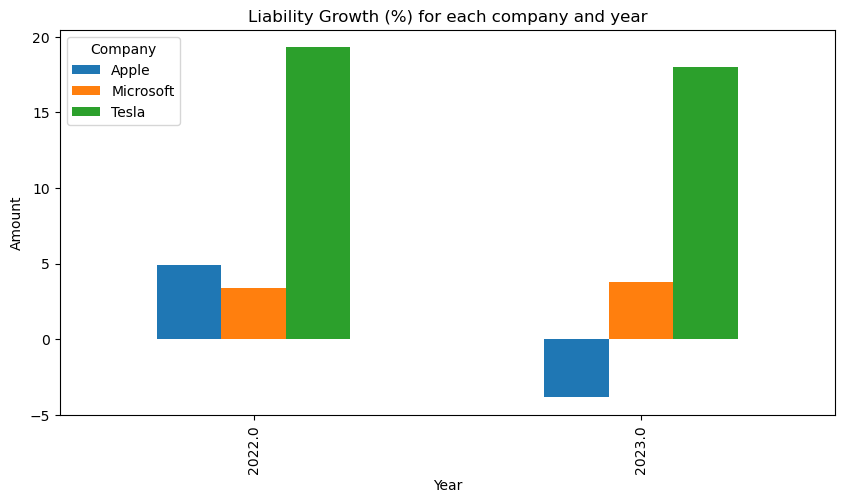

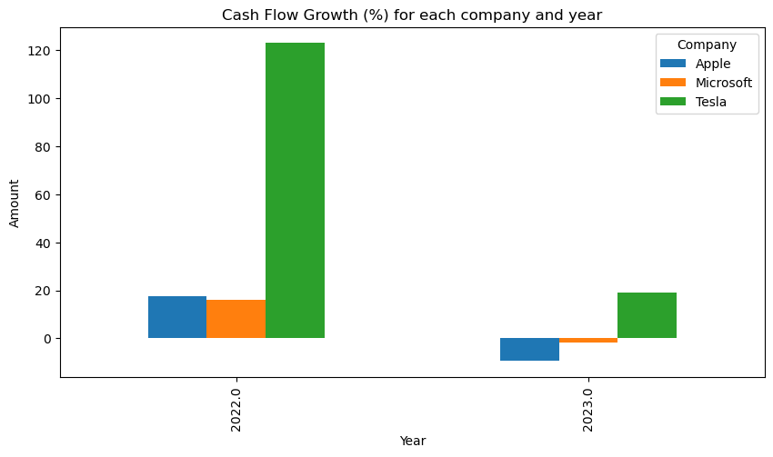

```python
createdcats = ["Revenue Growth (%)", "Net Income Growth (%)", "Asset Growth (%)", "Liability Growth (%)", "Cash Flow Growth (%)"]
for n in createdcats:
    df.dropna().groupby(['Year', 'Company'])[n].sum().unstack().plot(kind='bar', figsize=(10, 5))
    plt.title(str(n) + " for each company and year")
    plt.xlabel("Year")
    plt.ylabel('Amount')
    plt.show()
```